# Fontes de dados para o BEP

Author

Fernando Barbalho

## Objetivo

Comparar os dados do Boletim Estatístico de Pessoal (BEP) com outras fontes de dados buscando identificar quais fontes são compatívies com o BEP e identificar análises inovadoras em relação ao BEP e ao PEP que podem ser feitas a partir do acesso a uma base de dados aberta ao nível de servidor.

## Metodologia

Comparação dos seguintes aspectos de dados do BEP:

- Despesa de Pessoal
- Servidores
- Remuneração
- Concursos
- Cargos

As fontes dos dados para comparação são:

- BEP para o ano de 2016
- [Painel Estatístico de Pessoal](http://painel.pep.planejamento.gov.br) (PEP)
- [Portal da Transparência](https://portaldatransparencia.gov.br/download-de-dados/servidores)
- Dados abertos de [Despesas e transferências totais da União](https://www.tesourotransparente.gov.br/ckan/dataset/despesas-e-transferencias-totais)

## Despesa de Pessoal

Na comparação entre BEP e PEP os valores não são idênticos mas são aproximados

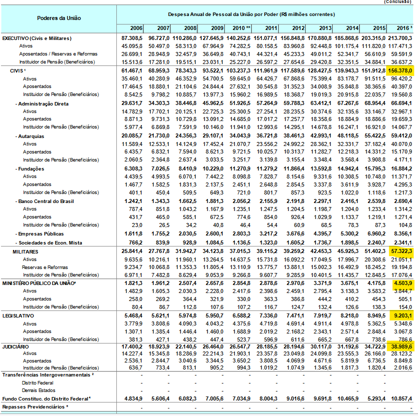

Despesa BEP

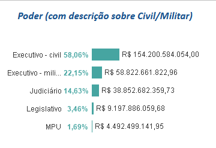

Despesa PEP

Na comparação entre BEP e dados de Despesas e transferências totais da União, os dados dos poderes legislativo , Judiciário e MPU aparentam estar próximos , porém o dado de poder executivo civil está com uma diferença de 10 bilhões de reais.

Veja abaixo os dados que vêm do portal Tesouro Transparente considerando os valores de gastos com servidores ativos

```r
rtn_despesas_primarias_ano_anterior<-
  readxl::read_xlsx("arquivo_despesa.xlsx", sheet = 2)


rtn_dimensional_ano_anterior<-
  rtn_despesas_primarias_ano_anterior %>%
  filter(CATEGORIA_RTN == "II.2.1 - Pessoal e Encargos Sociais - Ativo civil") %>%
  #mutate(Data = as.Date(paste(ID_ANO, ID_MES,"01",sep="-")) ) %>%
  group_by(PODER ) %>% # CATEGORIA_RTN,NO_FUNCAO_PT, ORGAO_DESCRICAO, NO_PROGRAMA_PT,NO_ACAO
  summarise(
    total_paga_ano = sum(DESPESAS_PAGAS/10^6),
    total_liquidado_ano = sum(DESPESAS_LIQUIDADAS/10^6)
  ) %>%
  ungroup() %>%
  arrange(desc(total_liquidado_ano))

kable(rtn_dimensional_ano_anterior)
```

| PODER | total_paga_ano | total_liquidado_ano |
| --- | --- | --- |
| EXE | 86642.34559 | 86860.17555 |
| JT | 9281.90318 | 9282.71017 |
| JF | 5944.77204 | 5946.96145 |
| MPU | 3264.76473 | 3264.76473 |
| JE | 3203.05405 | 3204.38770 |
| CD | 2482.20105 | 2482.20105 |
| SF | 1439.99440 | 1441.17685 |
| JDFT | 1358.86500 | 1358.87692 |
| TCU | 833.27060 | 833.27060 |
| STJ | 587.51555 | 587.51555 |
| STF | 216.10035 | 216.10035 |
| DPU | 188.50026 | 188.50026 |
| JM | 165.03802 | 165.03802 |
| CNJ | 50.62450 | 50.62450 |
| CNMP | 32.78837 | 32.78837 |

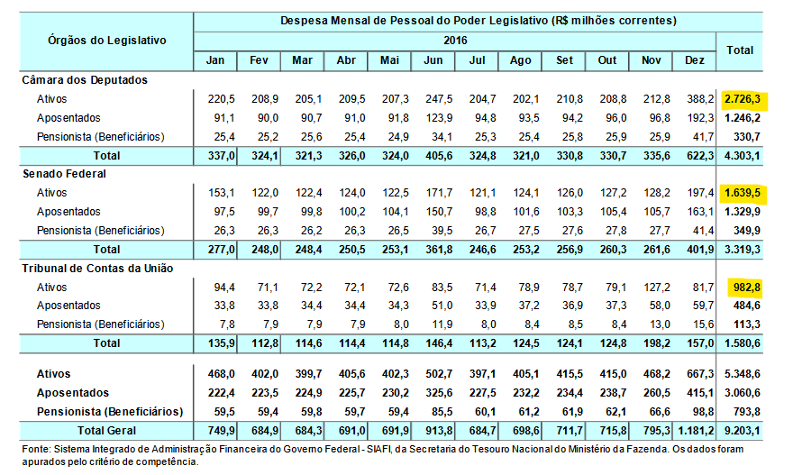

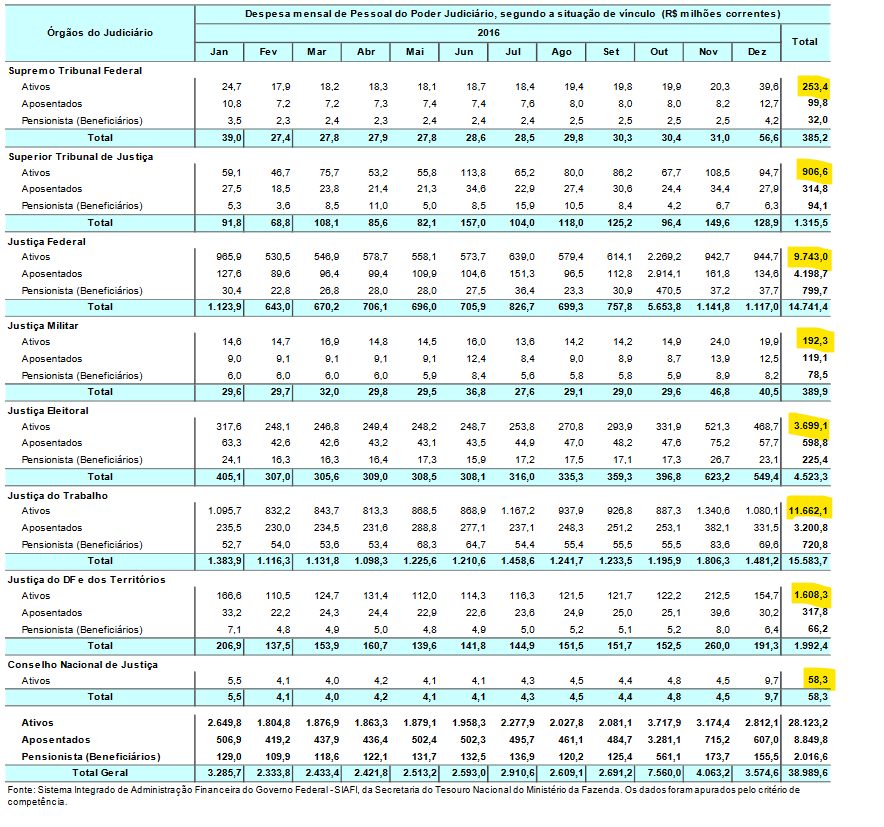

## Servidores

Em relação às quantidades de servidores há compatibilidade total entre o número de servidores civis do BEP e do PEP para 2016. Não consegui encontrar dados sobre servidores militares, Banco Central, legislativo e judiciário. Veja abaixo a comparação

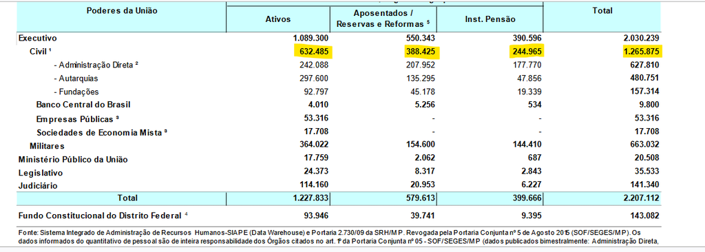

Servidores 2016 - BEP

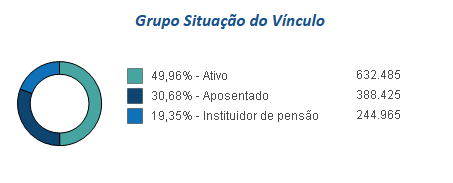

Servidores 2016 - PEP

Já em relação à tabela de cadastro de servidores públicos disponível a partir do Portal da Transparência, pode-se verificar que não há compatibilidade entre os dados em relação à estrutura dos órgãos superiores. No Portal da Transparência a estrutura mais atualizada disponível é refletida para todos os anos o que impede essa comparação. Veja abaixo os dados presentes no BEP para Dezembro de 2016.

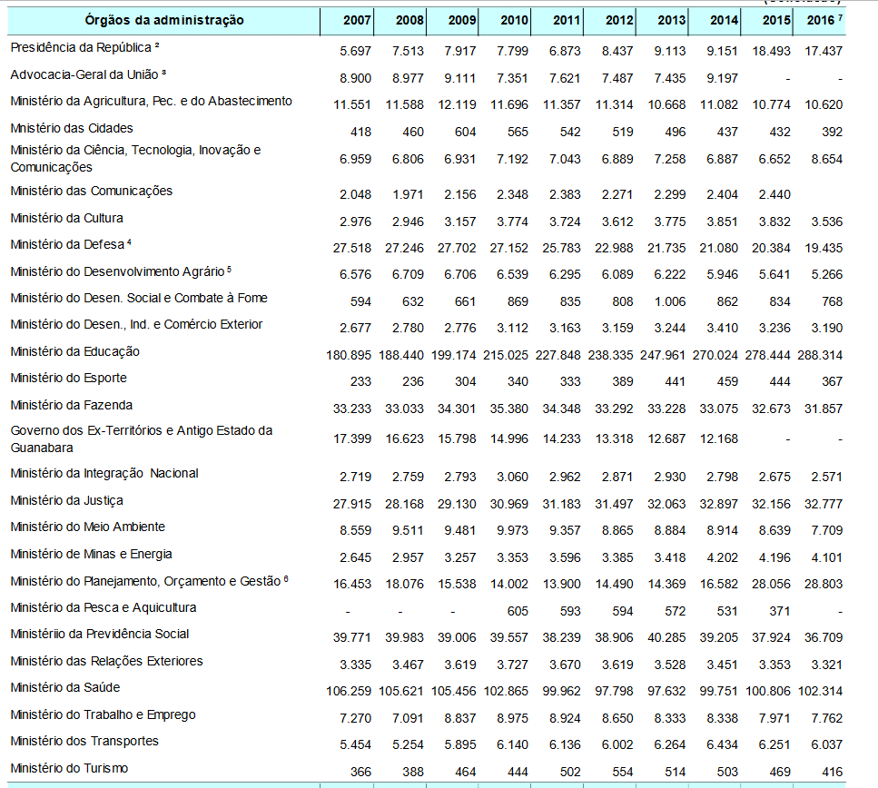

Órgãos superiores em dez 2016

E abaixo executamos o script que traz a totalização dos órgãos em Dezembro de 2016 na tabela do Portal da Transparência

```r
siape_201612_Cadastro<- busca_dados_cadastro("2016","12",FALSE)

siape_201612_Cadastro %>%
  distinct(orgsup_lotacao,
           id_servidor_portal) %>%
  group_by(orgsup_lotacao) %>%
  summarise(
    quantidade = n()
  ) %>%
  arrange(orgsup_lotacao) %>%
  kable()
```

| orgsup_lotacao | quantidade |
| --- | --- |
| Comando da Marinha | 1689 |
| Ministério da Agricultura, Pecuária e Abastecimento | 14773 |
| Ministério da Ciência, Tecnologia, Inovações e Comunicações | 6979 |
| Ministério da Cultura | 2743 |
| Ministério da Defesa | 18244 |
| Ministério da Economia | 11489 |
| Ministério da Educação | 316393 |
| Ministério da Indústria, Comércio Exterior e Serviços | 2496 |
| Ministério da Infraestrutura | 5226 |
| Ministério da Justiça e Segurança Pública | 2541 |
| Ministério da Previdência Social | 65 |
| Ministério da Saúde | 15412 |
| Ministério das Cidades | 5488 |
| Ministério das Relações Exteriores | 63 |
| Ministério de Minas e Energia | 5221 |
| Ministério do Desenvolvimento Regional | 3986 |
| Ministério do Desenvolvimento Social | 36359 |
| Ministério do Esporte | 50 |
| Ministério do Meio Ambiente | 7062 |
| Ministério do Planejamento, Desenvolvimento e Gestão | 24681 |
| Ministério do Turismo | 160 |
| Poder Executivo Federal | 1 |
| Presidência da República | 23162 |
| Sem informação | 161468 |

Na impossibilidade de se comparar diretamente BEP com os dados do Portal da Transparência, passa a ser interessante a comparação da tabela cadastro com o PEP para Janeiro de 2023 já que a estrutura de órgãos superiores é a mesma. Mesmo nesse caso não é possível fazer comparações pelo elevado número de servidores sem a correta associação aos **órgão superiores de lotação** o que gera elevado número de alocações com status de “Sem Informação”. Vide abaixo.

```r
siape_202301_Cadastro<- busca_dados_cadastro("2023","01", FALSE)

siape_202301_Cadastro %>%
  distinct(orgsup_lotacao,
           id_servidor_portal) %>%
  group_by(orgsup_lotacao) %>%
  summarise(
    quantidade = n()
  ) %>%
  arrange(desc(quantidade)) %>%
  kable()
```

| orgsup_lotacao | quantidade |
| --- | --- |
| Ministério da Educação | 340094 |
| Sem informação | 122269 |
| Ministério da Economia | 56055 |
| Ministério da Agricultura, Pecuária e Abastecimento | 14480 |
| Ministério da Defesa | 14266 |
| Presidência da República | 11442 |
| Ministério da Saúde | 9002 |
| Ministério da Infraestrutura | 8552 |
| Ministério do Meio Ambiente | 8362 |
| Ministério de Minas e Energia | 6893 |
| Ministério do Desenvolvimento Regional | 6840 |
| Ministério da Ciência, Tecnologia, Inovações e Comunicações | 4152 |
| Ministério do Turismo | 2462 |
| Ministério da Justiça e Segurança Pública | 2357 |
| Ministério da Previdência Social | 197 |
| Poder Executivo Federal | 76 |
| Ministério das Relações Exteriores | 56 |

Após a exploração dos dados, identifca-se facilmente que o problema de ausência de registro não ocorre no nível inferoir relatvio aos órgãos, mas ainda assim não há compatibilidade total entre o número de servidores no PEP e no Portal da Transparência. Veja abaixo uma tabela resumo do Portal da Transparência para órgãos de lotação.

```r
siape_202301_Cadastro %>%
  distinct(org_lotacao,
           id_servidor_portal) %>%
  group_by(org_lotacao) %>%
  summarise(
    quantidade = n()
  ) %>%
  arrange(desc(quantidade)) %>%
  slice_max(order_by = quantidade, n=10) %>%
  kable()
```

| org_lotacao | quantidade |
| --- | --- |
| Ministério da Saúde | 56487 |
| Empresa Brasileira de Serviços Hospitalares | 40683 |
| Ministério da Economia | 29040 |
| Instituto Nacional do Seguro Social | 24861 |
| Universidade Federal do Rio de Janeiro | 14107 |
| Fundação Instituto Brasileiro de Geografia e Estatística | 10682 |
| MINISTERIO DO TRABALHO E PREVIDENCIA | 8914 |
| Universidade Federal de Minas Gerais | 8031 |
| Empresa Brasileira de Pesquisa Agropecuária | 7892 |
| Advocacia-Geral da União | 7583 |

E abaixo um gráfico com o ranking presente no PEP para Janeiro de 2023.

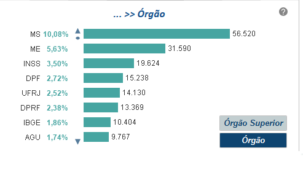

Quando se foca nas estatísticas por sexo, percebe-se que o Portal da Transparência não traz esse dado. Por outro lado, ao se comparar o BEP com o PEP vê-se que os valores totais não coincidem. Vide abaixo.

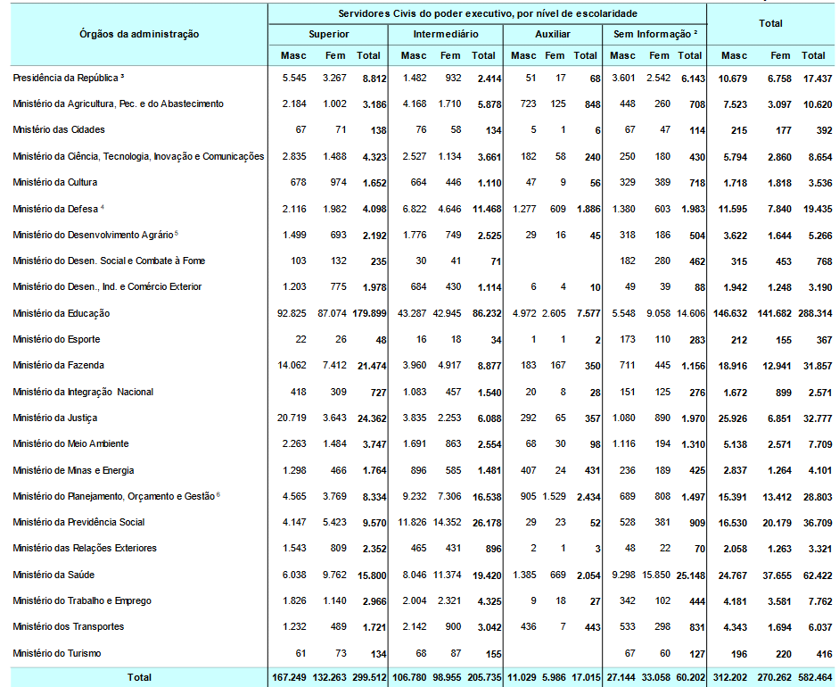

Distribuição por sexo - BEP 2016

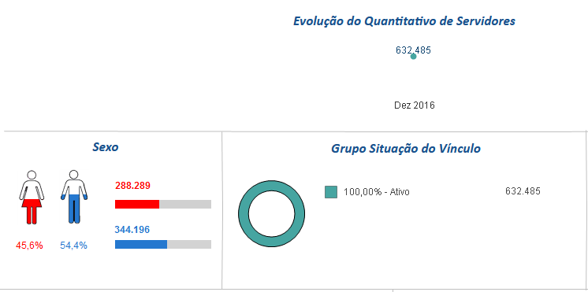

Distribuição por sexo - PEP 2016

Já em relação a idade, observa-se que não há esse dado no Portal da Transparência. O PEP tem esse dado mas o nível de granularidade da informação não permite comparação com o BEP. Veja abaixo duas figuras que evidenciam o problema.

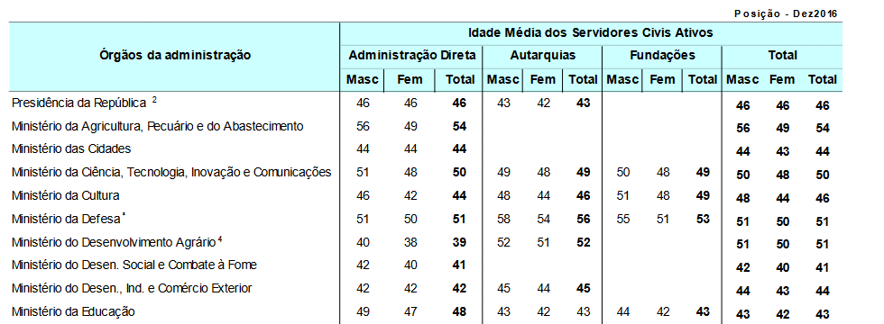

Idade média dos servidores - BEP 2016

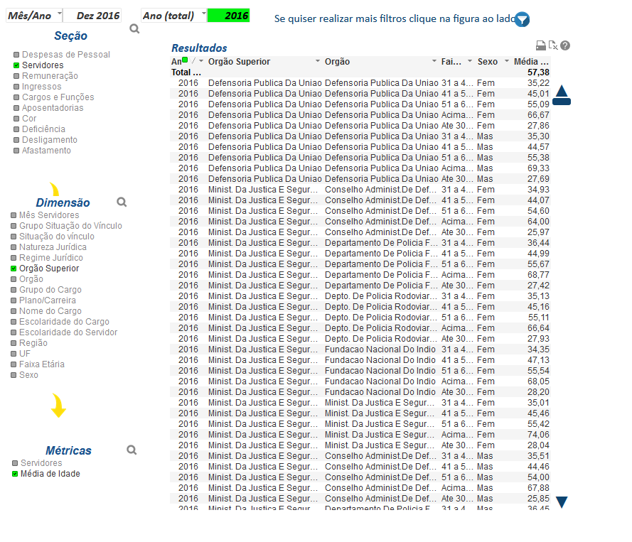

Idade média dos servidores - PEP 2016

## Remuneração

Em relação à remuneração, os dados disponibilizados pelo PEP não conseguem responder ao que é demandado na tabela 3.1 do BEP de Jan_2017. Também não é possível fazer comparações dos dados do BEP com PEP já que o primeiro mês disponível no PEP é janeiro de 2017 e o último mês para o BEP é dezembro de 2016.

```r
remuneracao_dez_2016 <- busca_dados_remuneracao("2016","12",FALSE)

cadastro_dez_2016<- busca_dados_cadastro("2016","12",FALSE)


join_tabelas_2016<-
  remuneracao_dez_2016 %>%
  inner_join(
    cadastro_dez_2016 %>%
      group_by(id_servidor_portal) %>%
      summarise(
        quantidade = n()
      ) %>%
      filter(quantidade == 1)
  ) %>%
  inner_join(cadastro_dez_2016, by= c("id_servidor_portal"))


##Testando a maior remuneração de carreira para AFFC
teste_affc_2016<-
  join_tabelas_2016 %>%
  filter(classe_cargo == "S",
         padrao_cargo == "IV",
         descricao_cargo == "AUDITOR FEDERAL DE FINANCAS E CONTROLE")

##A mediana é um bom proxy para a remuneração básica bruta do último nível da carreira. Para Dezembro de 2016 este valor bate no centavo
median(teste_affc_2016$remuneracao_basica_bruta_r)
```

```
[1] 22567.61
```

O valor da mediana indicado acima é 100% compatível com o valor máximo de remuneração para a carreira de AFFC em Dezembro de 2016 no BEP, conforme pode ser visto na figura abaixo.

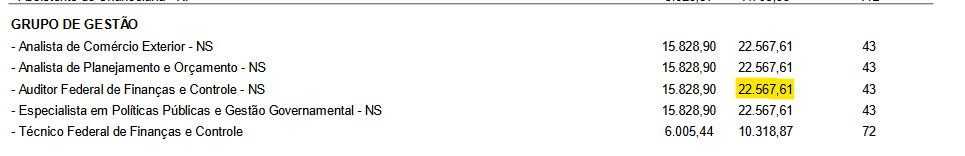

## Concursos

Em relação às entradas no serviço público por intermédio de concursos, a base do PEP é bastante compatível com a do BEP, muito embora não se chegue aos mesmos valores para algumas amostras levantadas. Veja as figuras abaixo onde se pode comparar o número de ingressos por concursos para as carreiras de Policial Federal e Policial Rodoviário Federal.

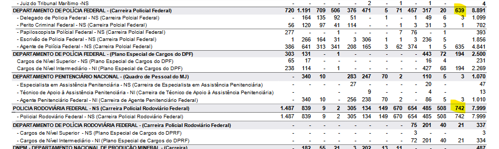

Concursos 2016 - BEP

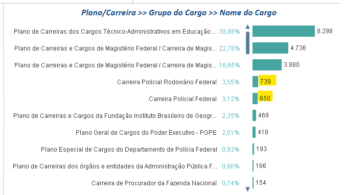

Concursos_2016_pep

Já em relação a análise a partir da tabela de Cadastro do Portal da Transparência, nota-se que a estrutura da tabela não permite se chegar à conclusões sobre o número de servidores que foram admitidos por concurso em um determinado período.

## Cargos

Quando se compara os dados de cargo entre BEP e PEP percebe-se grande compatibilidade para as amostras analisadas, com muitos dos cargos com quantitativos exibindo os mesmos valores. Por outro lado há diferença para o caso de DAS. Veja as figuras abaixo.

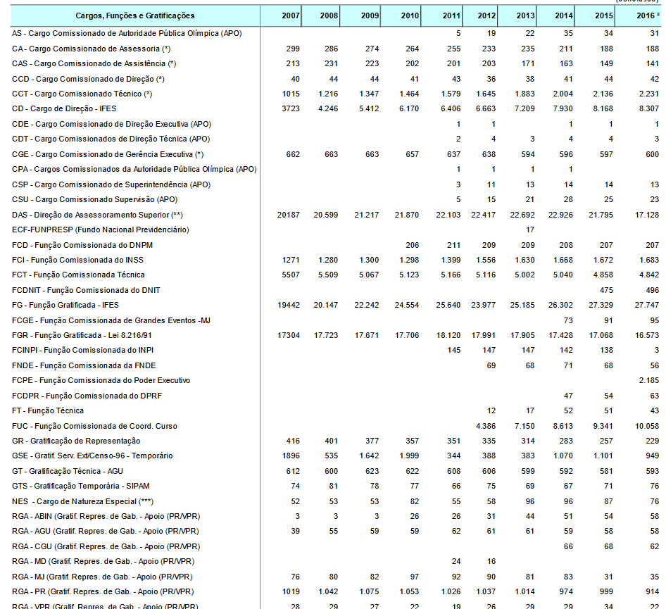

Cargos BEP - 2016

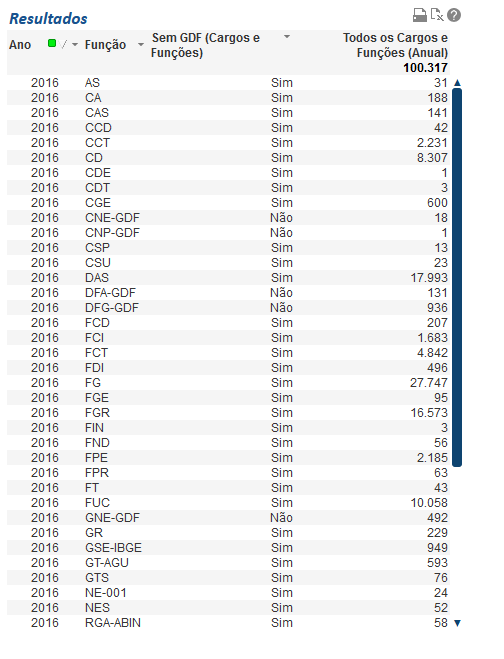

Cargos PEP - 2016

Quando a comparação é feita tendo como referência os dados do Portal da transparência, também se consegue perceber compatbilidades nos dados, mesmo que não seja total.

```r
cadastro_dez_2016 %>%
  filter(sigla_funcao != -1)%>%
  group_by(sigla_funcao,
           funcao) %>%
  summarise(
    quantidade = n()
  ) %>%
  arrange(sigla_funcao)%>%
  kable()
```

| sigla_funcao | funcao | quantidade |
| --- | --- | --- |
| AS | CARGO DE ASSESSORIA - CA/APO | 25 |
| CA | CARGO COMISSIONADO DE ASSESSORIA | 187 |
| CAS | CARGO COMISSIONADO DE ASSISTENCIA | 148 |
| CCD | CARGO COMISSIONADO DE DIRECAO | 45 |
| CCT | CARGO COMISSIONADO DE TECNICO | 2262 |
| CD | CARGO DE DIRECAO - CD - IFES | 8452 |
| CDT | CARGO DE DIRETOR TECNICO - CDT/APO | 2 |
| CGE | CARGO COMISS. DE GERENCIA EXECUTIVA | 613 |
| CSP | CARGO DE SUPERINTENDENTE - CSP/APO | 6 |
| CSU | CARGO DE SUPERVISOR - CSU/APO | 17 |
| CTE | CARGO COMISSIONADO TEMPORARIO | 144 |
| DAS | DIRECAO E ASSESSORAMENTO SUPERIOR | 18350 |
| EC | EMPREGO EM COMISSAO | 18 |
| FAA | FUNCAO DE ASSESSORIA E APOIO | 66 |
| FCA | FCA | 1 |
| FCC | FCC | 6 |
| FCD | FUNCAO COMISSIONADA DO DNPM - FCDNPM | 208 |
| FCE | FUNC DE CONFIANCA-GRAT DL 2355-EMP | 44 |
| FCI | FCINSS - FUNCAO COMISSIONADA INSS | 1691 |
| FCL | FCL | 1 |
| FCT | FUNCAO COMISSIONADA TECNICA | 4865 |
| FDI | FCDNIT - FUNC.COMISSIONADA DNIT | 501 |
| FG | FUNCAO GRATIFICADA - IFES | 28169 |
| FGC | FUNÇÃO GRATIFICADA CEITEC | 39 |
| FGE | FUNCAO COMISSIONADA DE GRANDES EVENTOS | 59 |
| FGI | FUNCAO GRATIFICADA QUADRO INICIAL | 1 |
| FGP | FUNCAO GRATIFICADA QUADRO PERMANENTE | 68 |
| FGR | FUNCAO GRATIFICADA LEI 8.216/91 | 15354 |
| FGS | FUNCAO DE GESTAO | 17 |
| FIN | FUNCAO COMISSIONADA DO INPI - FCINPI | 20 |
| FND | FUNCAO COMISSIONADA - FNDE | 57 |
| FPE | FUNCAO COMISSIONADA DO PODER EXECUTIVO | 2189 |
| FTS | FUNCAO TECNICA | 48 |
| FUC | FUNCAO COMISSIONADA DE COORD. CURSO | 10270 |
| GF | FUNCAO GRATIFICADA | 4067 |
| GFC | GRATIFICACAO DE FUNCAO DE CONFIANCA | 985 |
| GR | GRATIFICACAO DE REPRESENTACAO | 229 |
| GSE | GRAT SERV EXT/CENSO-96 - TEMPORARIA | 955 |
| GT | GRATIFICACAO TEMPORARIA | 595 |
| GTS | GRATIFICACAO TEMPORARIA - SIPAM | 75 |
| NES | CARGO DE NATUREZA ESPECIAL | 58 |
| PCC | PLANO DE CARGOS EM COMISSAO | 36 |
| PFC | PLANO DE FUNCOES DE CONFIANCA | 333 |
| PFG | PLANO DE FUNCOES GRATIFICADAS | 278 |
| RGA | GRATIF. REPRES. DE GAB. - APOIO(PR/VPR) | 1072 |
| RGM | GRATIF. REPRESENTACAO DE GABINETE (MIN) | 326 |
| RMA | GRATIF.REPRES.GAB. - APOIO MILITAR | 1296 |
| RMP | GRATIF. REPRES. GABINETE - MILITAR | 480 |

```r
####Os dados de função da tabela de cadastro aproximam-se dos dados do BEP
####Os dados do PEP batem com os dados do BEP
```

## Aposentadorias

Quando se compara os números de aposentadorias para o ano de 2016 do PEP com o BEP percebe-se que os valores estão bastante próximos. Vide figuras abaixo.

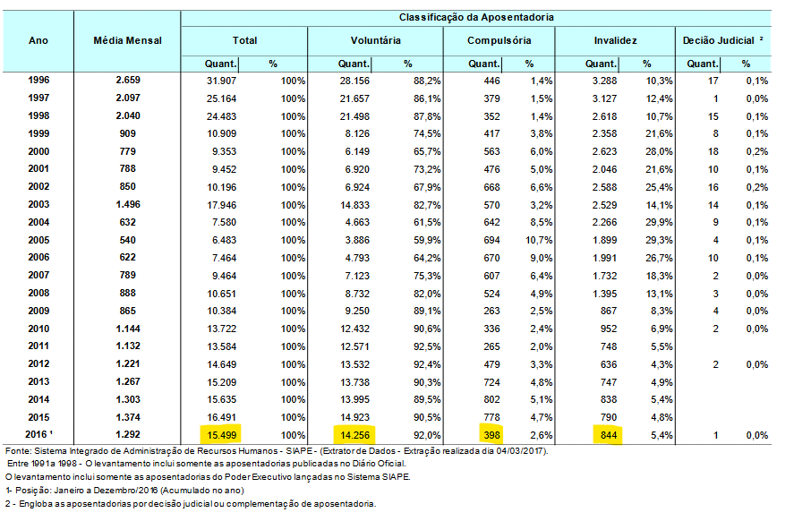

Aposentadorias 2016 - BEP

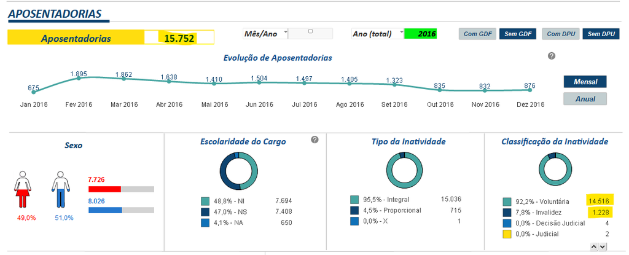

Aposentadorias 2016 - PEP

Quando se trabalha com os dados de aposentados presentes no Portal da Transparência encontramos dois fatores impeditivos para fazer comparações com o BEP. O primeiro é que a estrutura dos dados não permite identificar os servidores que se aposentaram em um determinado período. O segundo fator é que não existem dados de aposentados para Dezembro de 2016 no Portal da Transparência.

## Inovações nas análises com dados do portal da transparência

Os dados das tabelas do Portal da Transparência possuem granularidade relacionados a servidor. Isso permite uma maior possibilidadde de análise de dados que estejam associados a estatísticas de distribuição das variáveis. Além disso, o Portal da Transparência possui alguns campos que não estão ativos nem no PEP nem no GEP. Veja abaixo alguns gráficos que foram construídos somente com os dados do Portal da Transparência seguido de uma rápida análise sobre o que se pode extrair das figuras.

**Tabelas de Cadastro e remuneração**

Na primeira análise vamos comparar a evolução da quantidade e remuneração de servidores que são Auditor Federal de Finanças e Controle (AFFC) de acordo com o nível de carreira. Comparamos nesse caso os dados para Dezembro de 2016 e Janeiro de 2023

*Dados para 2016*

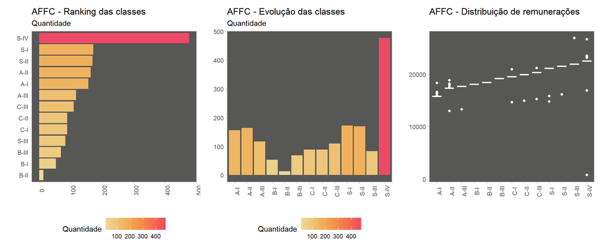

```r
library(patchwork)
library(colorspace)

graf_a<-
join_tabelas_2016 %>%
  filter(descricao_cargo == "AUDITOR FEDERAL DE FINANCAS E CONTROLE") %>%
  mutate(posicao_carreira = str_c(classe_cargo,"-",padrao_cargo)) %>%
  group_by(posicao_carreira) %>%
  summarise(
    quantidade = n()
  ) %>%
  ungroup() %>%
  mutate(posicao_carreira = reorder(posicao_carreira, quantidade)) %>%
  ggplot(aes(x=quantidade, y=posicao_carreira, fill= quantidade )) +
  geom_col() +
  scale_fill_continuous_sequential(palette = "OrYel") +
  theme_light() +
  theme(
    panel.background = element_rect(fill = "#575756"),
    panel.grid = element_blank(),
    axis.text.x = element_text(angle = 90),
    legend.position = "bottom"
  ) +
  labs(
    title= "AFFC - Ranking das classes",
    subtitle = "Quantidade",
    fill = "Quantidade",
    x="",
    y=""
  )

graf_b<-
join_tabelas_2016 %>%
  filter(descricao_cargo == "AUDITOR FEDERAL DE FINANCAS E CONTROLE") %>%
  mutate(posicao_carreira = str_c(classe_cargo,"-",padrao_cargo)) %>%
  group_by(posicao_carreira) %>%
  summarise(
    quantidade = n()
  ) %>%
  ungroup() %>%
  ggplot(aes(x=posicao_carreira,y=quantidade,  fill= quantidade )) +
  geom_col() +
  scale_fill_continuous_sequential(palette = "OrYel") +
  theme_light() +
  theme(
    panel.background = element_rect(fill = "#575756"),
    panel.grid = element_blank(),
    axis.text.x = element_text(angle = 90),
    legend.position = "bottom"
  ) +
  labs(
    title= "AFFC - Evolução das classes",
    subtitle = "Quantidade",
    fill = "Quantidade",
    x="",
    y=""
  )

graf_c<-
join_tabelas_2016 %>%
  filter(descricao_cargo == "AUDITOR FEDERAL DE FINANCAS E CONTROLE") %>%
  mutate(posicao_carreira = str_c(classe_cargo,"-",padrao_cargo)) %>%
  ungroup() %>%
  ggplot(aes(x=posicao_carreira,y=remuneracao_basica_bruta_r, )) +
  geom_boxplot(color= "white") +

  theme_light() +
  theme(
    panel.background = element_rect(fill = "#575756"),
    panel.grid = element_blank(),
    axis.text.x = element_text(angle = 90),
    legend.position = "bottom"
  ) +
  labs(
    title= "AFFC - Distribuição de remunerações",
    x="",
    y=""
  )

graf_a|graf_b|graf_c
```

*Dados para 2023*

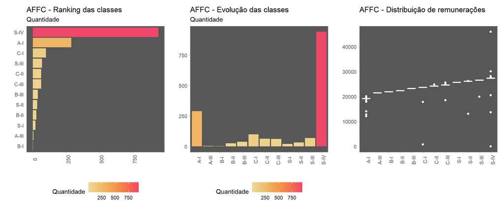

```r
remuneracao_jan_2023 <- busca_dados_remuneracao("2023","01",FALSE)

cadastro_jan_2023<- busca_dados_cadastro("2023","01",FALSE)


join_tabelas<-
remuneracao_jan_2023 %>%
  inner_join(
    cadastro_jan_2023 %>%
      group_by(id_servidor_portal) %>%
      summarise(
        quantidade = n()
      ) %>%
      filter(quantidade == 1)
  ) %>%
  inner_join(cadastro_jan_2023, by= c("id_servidor_portal"))

graf_a<-
join_tabelas %>%
  filter(descricao_cargo == "AUDITOR FEDERAL DE FINANCAS E CONTROLE") %>%
  mutate(posicao_carreira = str_c(classe_cargo,"-",padrao_cargo)) %>%
  group_by(posicao_carreira) %>%
  summarise(
    quantidade = n()
  ) %>%
  ungroup() %>%
  mutate(posicao_carreira = reorder(posicao_carreira, quantidade)) %>%
  ggplot(aes(x=quantidade, y=posicao_carreira, fill= quantidade )) +
  geom_col() +
  scale_fill_continuous_sequential(palette = "OrYel") +
  theme_light() +
  theme(
    panel.background = element_rect(fill = "#575756"),
    panel.grid = element_blank(),
    axis.text.x = element_text(angle = 90),
    legend.position = "bottom"
  ) +
  labs(
    title= "AFFC - Ranking das classes",
    subtitle = "Quantidade",
    fill = "Quantidade",
    x="",
    y=""
  )

graf_b<-
join_tabelas %>%
  filter(descricao_cargo == "AUDITOR FEDERAL DE FINANCAS E CONTROLE") %>%
  mutate(posicao_carreira = str_c(classe_cargo,"-",padrao_cargo)) %>%
  group_by(posicao_carreira) %>%
  summarise(
    quantidade = n()
  ) %>%
  ungroup() %>%
  ggplot(aes(x=posicao_carreira,y=quantidade,  fill= quantidade )) +
  geom_col() +
  scale_fill_continuous_sequential(palette = "OrYel") +
  theme_light() +
  theme(
    panel.background = element_rect(fill = "#575756"),
    panel.grid = element_blank(),
    axis.text.x = element_text(angle = 90),
    legend.position = "bottom"
  ) +
  labs(
    title= "AFFC - Evolução das classes",
    subtitle = "Quantidade",
    fill = "Quantidade",
    x="",
    y=""
  )

graf_c<-
join_tabelas %>%
  filter(descricao_cargo == "AUDITOR FEDERAL DE FINANCAS E CONTROLE") %>%
  mutate(posicao_carreira = str_c(classe_cargo,"-",padrao_cargo)) %>%
  ungroup() %>%
  ggplot(aes(x=posicao_carreira,y=remuneracao_basica_bruta_r, )) +
  geom_boxplot(color= "white") +

  theme_light() +
  theme(
    panel.background = element_rect(fill = "#575756"),
    panel.grid = element_blank(),
    axis.text.x = element_text(angle = 90),
    legend.position = "bottom"
  ) +
  labs(
    title= "AFFC - Distribuição de remunerações",
    x="",
    y=""
  )

graf_a|graf_b|graf_c
```

Percebe-se pelos gráficos que a carreira está se concentrando cada vez mais no seu último estágio, havendo portanto uma possível falta de renovação.

Ao se observar o acompanhamento da rentabilidade bruta, percebe-se que as medianas não sofreram alterações fortes, com o destaque para a ocorrência de poucos outliers importantes

**Aposentadorias**

Como já indicado em parágrafos anteriores, não é possível fazer comparações entre dados Por outro lado, os dados disponíveis no Portal da Transparência permitem verificar a quantidade de aposentadorias pagas em um determinado mês, bem como é possível fazer levantamentos estatísticos sobre os valores pagos.

Veja abaixo a quantidade de aposentadorias pagas para Dezembro de 2022

```r
aposentados_dez_2022<-
  busca_dados_aposentadoria("2022","12")
```

```
[1] "https://portaldatransparencia.gov.br/download-de-dados/servidores/202212_Aposentados_SIAPE"
```

```r
NROW(unique(aposentados_dez_2022$id_servidor_portal))
```

```
[1] 410011
```

E logo abaixo uma visualização que mostra a distribuição de remuneração bruta também para Dezembro de 2022.

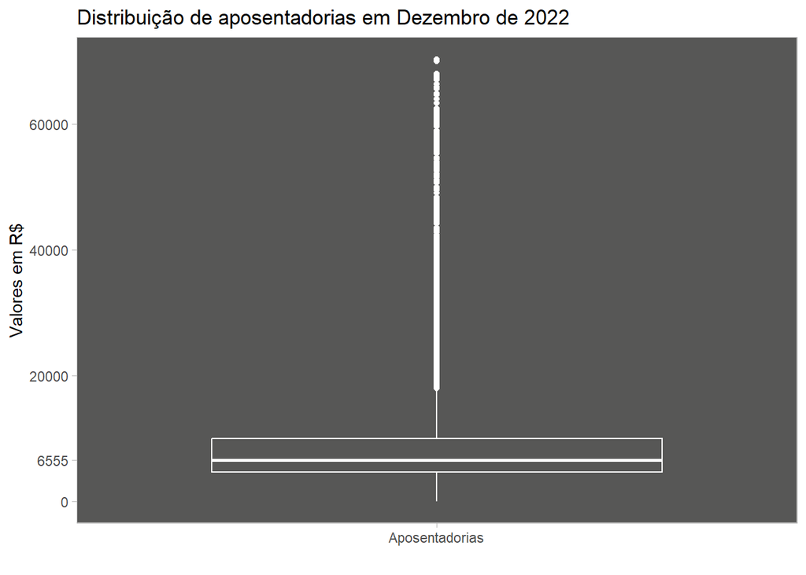

```r
mediana_bruta<-
  round(median(aposentados_dez_2022$remuneracao_basica_bruta_r, na.rm = TRUE),0)

aposentados_dez_2022%>%
  mutate(categoria = "Aposentadorias") %>%
  #filter(remuneracao_apos_deducoes_obrigatorias_r>0) %>%
  ggplot(aes(x=categoria,y=remuneracao_basica_bruta_r )) +
  geom_boxplot(fill= NA, color= "white")+
  scale_y_continuous(breaks = c(seq(0,60000,20000), mediana_bruta))+
  theme_light() +
  theme(
    panel.background = element_rect(fill = "#575756"),
    panel.grid = element_blank(),
    legend.position = "bottom"
  ) +
  labs(
    title= "Distribuição de aposentadorias em Dezembro de 2022",
    x="",
    y="Valores em R$"
  )
```

**Fluxo de servidores**

Quais são os maiores fluxos de servidores entre órgãos de lotação e órgãos de exercício? Essa também é uma pergunta que pode ser respondida usando os dados com a granularidade da tabela de servidores vinda do Portal da Transparência. Veja abaixo o caso de Janeiro de 2023 para os nove órgãos que mais fornecem servidores para outros órgãos.O gráfico abaixo é dinâmico você pode ajustar a posição das caixas que representam os órgãos para cima ou para baixo para ver melhor o nome dos órgãos. Experimente também repousar o mouse sobre as faixas que ligam duas caixas para saber o número de servidores envolvidos na relação entre os dois órgãos representados pelas caixas.

[interactive chart not shown]

Podemos explorar melhor o que caracteriza o fenômeno da alocação de pessoas do Ministério da saúde em Estados, municípios e empresas

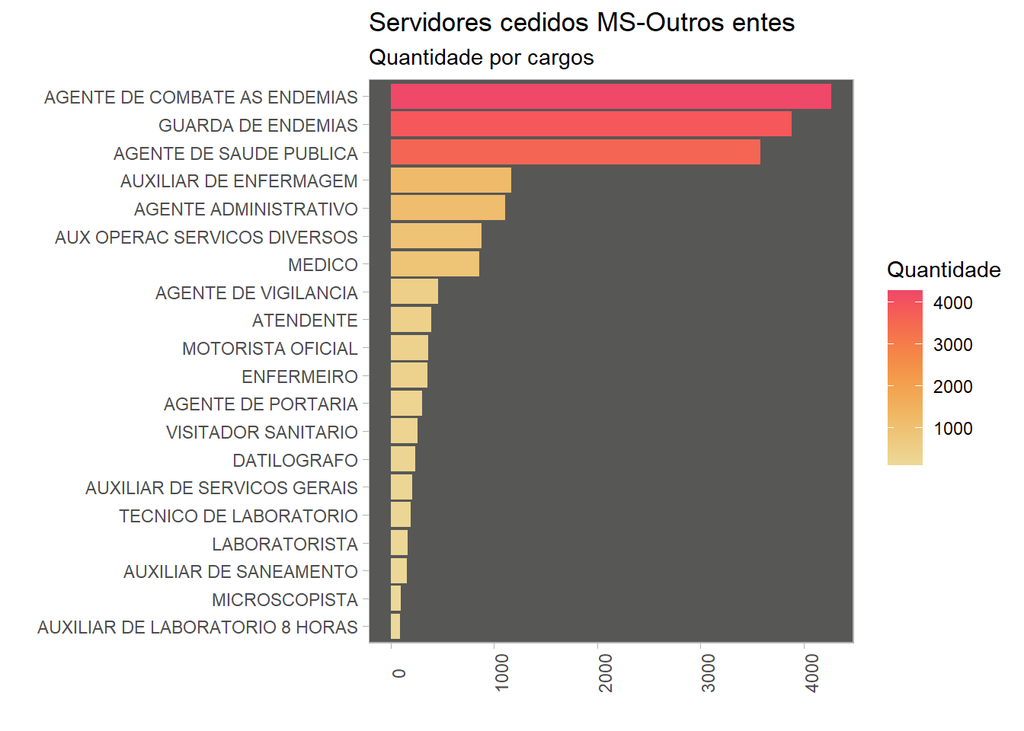

```r
library(colorspace)

siape_202301_Cadastro %>%
  filter(cod_org_lotacao == 25000,
         cod_org_exercicio == 99991) %>%
  distinct(id_servidor_portal, descricao_cargo) %>%
  group_by(descricao_cargo) %>%
  summarise(
    quantidade = n()
  )%>%
  ungroup() %>%
  slice_max(quantidade, n=20) %>%
  mutate(descricao_cargo= reorder(descricao_cargo,quantidade)) %>%
  ggplot(aes(x=quantidade, y=descricao_cargo, fill= quantidade )) +
  geom_col() +
  scale_fill_continuous_sequential(palette = "OrYel") +
  theme_light() +
  theme(
    panel.background = element_rect(fill = "#575756"),
    panel.grid = element_blank(),
    axis.text.x = element_text(angle = 90)
  ) +
  labs(
    title= "Servidores cedidos MS-Outros entes",
    subtitle = "Quantidade por cargos",
    fill = "Quantidade",
    x="",
    y=""
  )
```

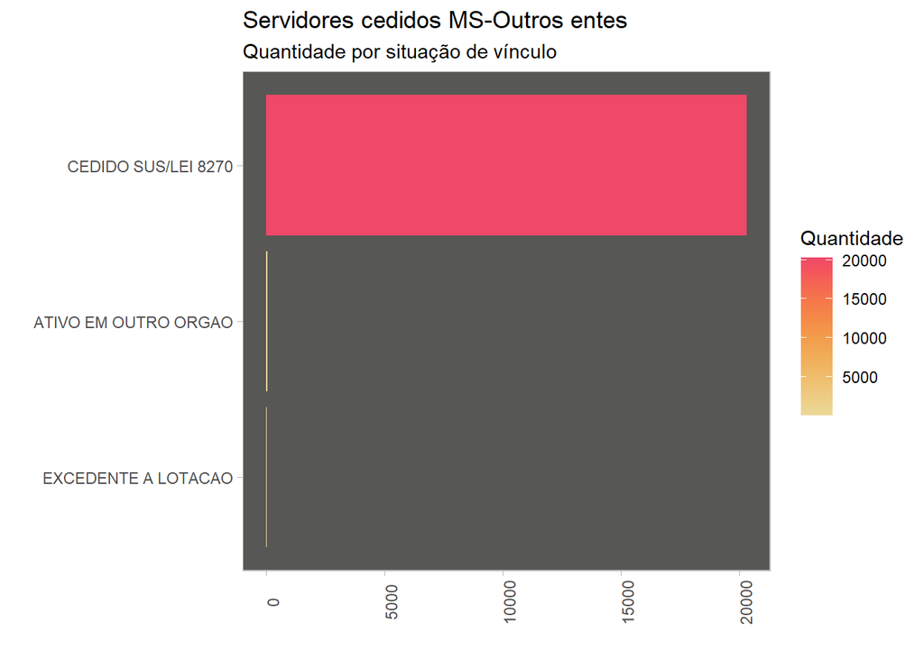

```r
siape_202301_Cadastro %>%
  filter(cod_org_lotacao == 25000,
         cod_org_exercicio == 99991) %>%
  distinct(id_servidor_portal, situacao_vinculo) %>%
  group_by(situacao_vinculo) %>%
  summarise(
    quantidade = n()
  )%>%
  ungroup() %>%
  slice_max(quantidade, n=20) %>%
  mutate(situacao_vinculo= reorder(situacao_vinculo,quantidade)) %>%
  ggplot(aes(x=quantidade, y=situacao_vinculo, fill= quantidade )) +
  geom_col() +
  scale_fill_continuous_sequential(palette = "OrYel") +
  theme_light() +
  theme(
    panel.background = element_rect(fill = "#575756"),
    panel.grid = element_blank(),
    axis.text.x = element_text(angle = 90)
  ) +
  labs(
    title= "Servidores cedidos MS-Outros entes",
    subtitle = "Quantidade por situação de vínculo",
    fill = "Quantidade",
    x="",
    y=""
  )
```

Assim como também podemos fazer comparações com o quadro do último ano completo do governo Dilma

Primeiro o fluxo de servidores entre órgãos de governo.

```r
dados_dez_2015<-
  busca_dados_cadastro(ano="2015", mes="12", FALSE)


max_fornecedor_dez_2015<-
dados_dez_2015 %>%
  filter(org_lotacao != org_exercicio) %>%
  distinct(id_servidor_portal, org_lotacao, org_exercicio) %>%
  group_by(org_lotacao, org_exercicio) %>%
  summarise(
    quantidade = n()
  ) %>%
  ungroup() %>%
  slice_max(order_by = quantidade, n=12) %>%
  distinct(org_lotacao, org_exercicio, quantidade)






orgaos_nodes<- unique(c(unique(max_fornecedor_dez_2015$org_lotacao), unique(max_fornecedor_dez_2015$org_exercicio)))

df_orgaos_nodes<- tibble(name=orgaos_nodes, index=0:(length(orgaos_nodes)-1))



orgaos_links<-
  max_fornecedor_dez_2015 %>%
  select(org_lotacao) %>%
  inner_join(
    df_orgaos_nodes,
    by= join_by(org_lotacao == name)
  ) %>%
  rename(source = index) %>%
  select(source) %>%
  bind_cols(
    max_fornecedor_dez_2015 %>%
      select(org_exercicio, quantidade) %>%
      inner_join(
        df_orgaos_nodes,
        by= join_by(org_exercicio == name)
      ) %>%
      rename(target = index) %>%
      select(target, quantidade)
  )




# Plot
 sankeyNetwork(Links = orgaos_links, Nodes = df_orgaos_nodes, Source = "source",
               Target = "target", Value = "quantidade", NodeID = "name",
               units = "", fontSize = 12, nodeWidth = 30)
```

[interactive chart not shown]

E abaixo a distribuição dos servidores ligados à saúde no fluxo para os municípios

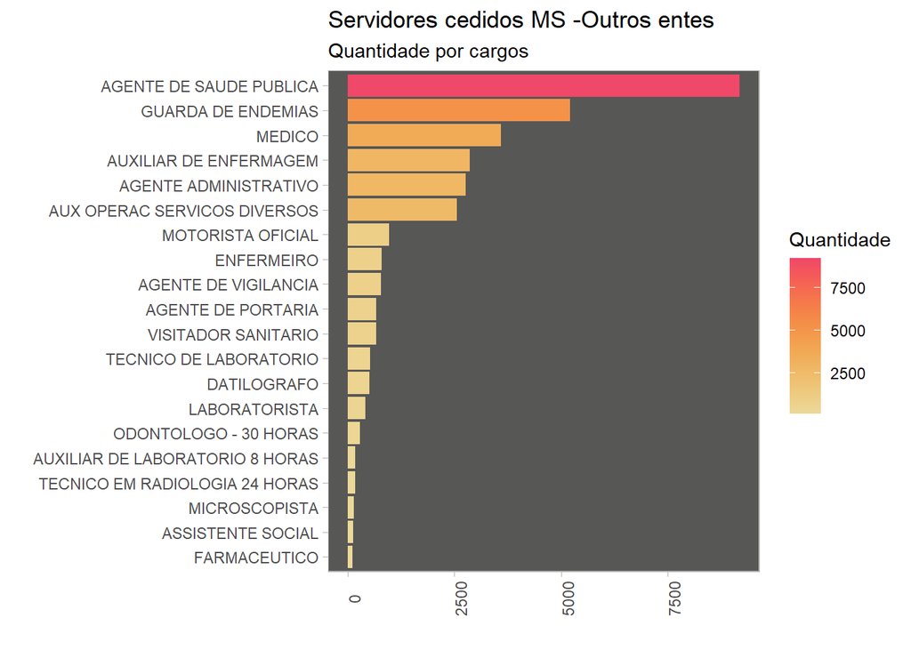

```r
dados_dez_2015 %>%
  filter(cod_org_lotacao == 25000 ,
         cod_org_exercicio == 99991) %>%
  distinct(id_servidor_portal, descricao_cargo) %>%
  group_by(descricao_cargo) %>%
  summarise(
    quantidade = n()
  )%>%
  ungroup() %>%
  slice_max(quantidade, n=20) %>%
  mutate(descricao_cargo= reorder(descricao_cargo,quantidade)) %>%
  ggplot(aes(x=quantidade, y=descricao_cargo, fill= quantidade )) +
  geom_col() +
  scale_fill_continuous_sequential(palette = "OrYel") +
  theme_light() +
  theme(
    panel.background = element_rect(fill = "#575756"),
    panel.grid = element_blank(),
    axis.text.x = element_text(angle = 90)
  ) +
  labs(
    title= "Servidores cedidos MS -Outros entes",
    subtitle = "Quantidade por cargos",
    fill = "Quantidade",
    x="",
    y=""
  )
```

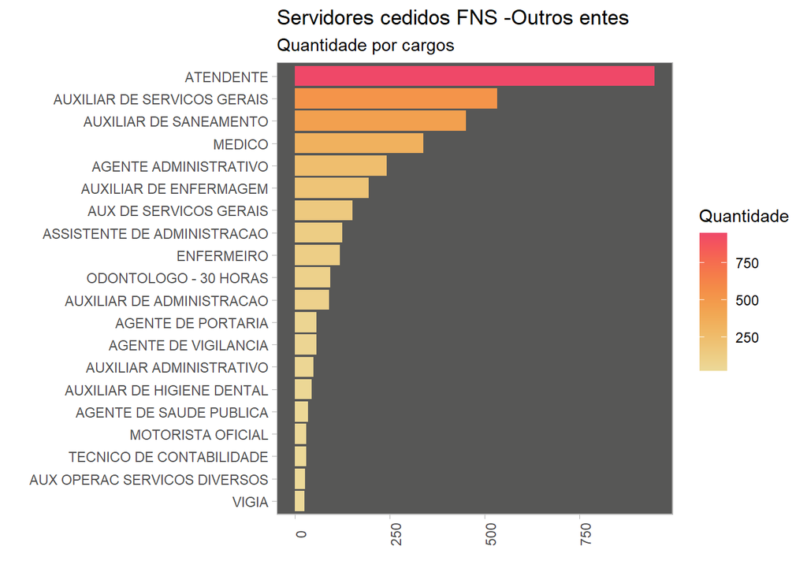

```r
dados_dez_2015 %>%
  filter( cod_org_lotacao == 36205,
         cod_org_exercicio == 99991) %>%
  distinct(id_servidor_portal, descricao_cargo) %>%
  group_by(descricao_cargo) %>%
  summarise(
    quantidade = n()
  )%>%
  ungroup() %>%
  slice_max(quantidade, n=20) %>%
  mutate(descricao_cargo= reorder(descricao_cargo,quantidade)) %>%
  ggplot(aes(x=quantidade, y=descricao_cargo, fill= quantidade )) +
  geom_col() +
  scale_fill_continuous_sequential(palette = "OrYel") +
  theme_light() +
  theme(
    panel.background = element_rect(fill = "#575756"),
    panel.grid = element_blank(),
    axis.text.x = element_text(angle = 90)
  ) +
  labs(
    title= "Servidores cedidos FNS -Outros entes",
    subtitle = "Quantidade por cargos",
    fill = "Quantidade",
    x="",
    y=""
  )
```

## Algumas questões

- Como acompanhar as mudanças de estruturas ao longo dos anos
- Como identificar algum órgão específico que é sabido existir pela tabela de órgãos mas não está presente na tabela do SIAPE. Por exemplo, SPU não aparece em nenhuma coluna
- Em outras palavras, como se resolve as relações entre códigos de órgãos de SIAPE, tabela de órgãos e SIAFI?